# Firefighting Drone with Reinforcement Learning based Control

## Tomasz Lewicki

## Motivation: Wildfire Problem

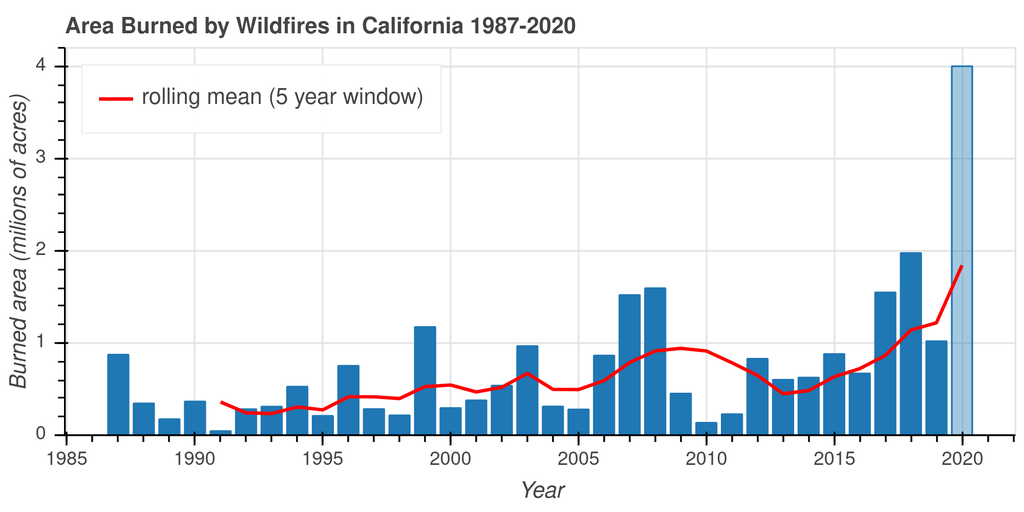

### Motivation: Drones as a potential solution

1. can access difficult to reach places
2. can be sent to more dangerous scenarios

### Topic inspired by my thesis project. In short:

- a drone with Nvidia GPU processing onboard
- Deep-CNN based infrared + RGB spectrum fire detection
- capable of detecting fire in at $>95 \%$ accuracy *(validated over a real fire incident)*

We have a perception system, let's build on top of that. Let's generate dynamic trajectories for a firefighting drone, based of these fire detections.

*(none of the components here are overlapping with my thesis)*

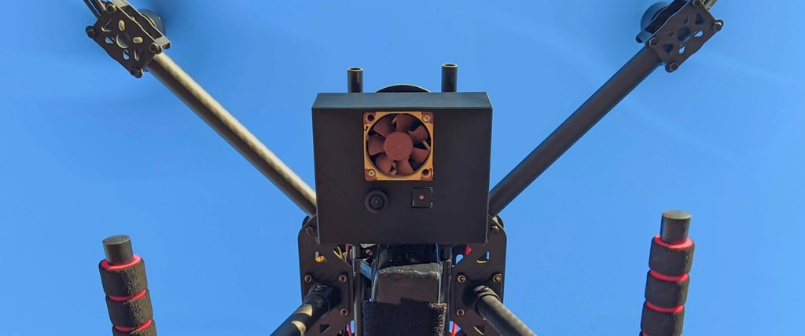

# Environment

### Environment Model

- cellular simulation of a wildfire
- on $N \times N$ grid lattice
- each cell has:
  - state $ s \in \{0,1\}$ (i.e. `intact` or `burning`)
  - fuel $ f \in [0,255]$
- in each step, every `burning` cell:
  - looses `burn_rate` amount of fuel
  - sets neighboring cells on fire with certain probability $p \in [0,1]$

### Not limited to wildfires!

- imagine cells can be shuffled (travel)
- we have a classic SIR* epidemic model where fire is the virus

**(SIR = Susceptible-Infectious-Removed)*

### More info:

**Julian and Kochenderfer** *Distributed Wildfire Surveillance with AutonomousAircraft using Deep Reinforcement Learning* https://arxiv.org/abs/1810.04244

**Haksar and Schwager** *Distributed Deep Reinforcement Learning for Fighting Forest Fires with a Network of Aerial Robots* https://msl.stanford.edu/sites/g/files/sbiybj8446/f/root_0.pdf

# Environment Demo

```python
from environment import Environment

# Initialize environment with 10k cells
env = Environment(shape=(100, 100), tree_density=0.55, random_seed=260)
```

# Environment API

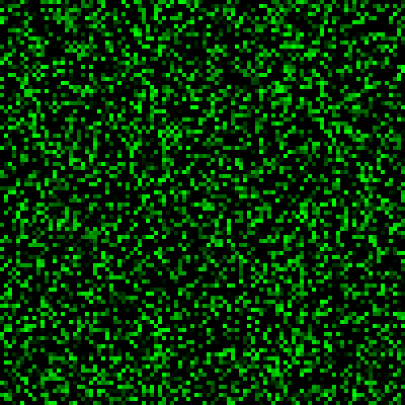

```python
# Image with the map of fuel ("forrest") 45% cells are empty
# and 55% have amounts of fuel drawn from uniform distribution
env.fuel()
```

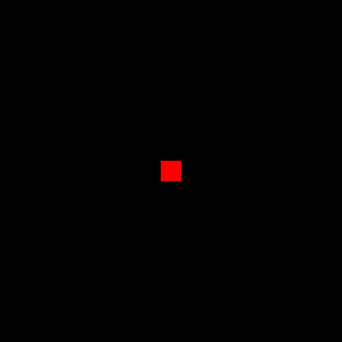

```python
# With .fire() method we can see the rendered map of fire
env.fire()
```

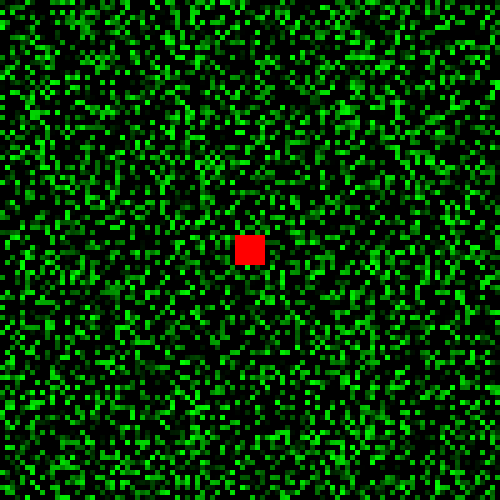

```python
# Finally, .snapshot() method has shows combined view
env.snapshot()
```

### Let's run a few steps

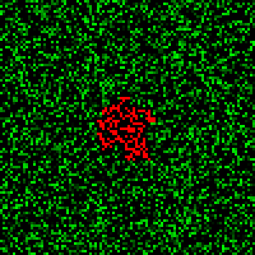

```python
for _ in range(10):
    env.simulation_step()

env.snapshot()
```

### Let's run some more steps

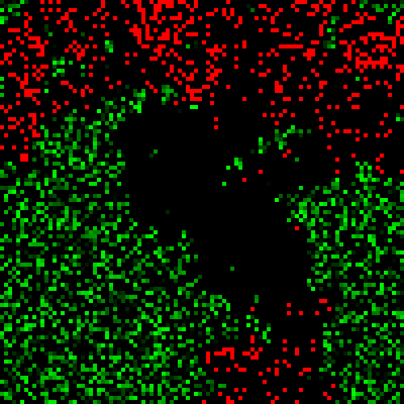

```python
for _ in range(100):
    env.simulation_step()
env.snapshot() # The wildfire simulation is unpredictable & extremely highly sensitive to initial conditions (just like in reality)
```

# Performance

```python
# 10 000 cells @ ~2000 FPS
%timeit env.simulation_step()
```

```
562 µs ± 6.78 µs per loop (mean ± std. dev. of 7 runs, 1000 loops each)
```

```python
# 1M cells @ ~20FPS
env = Environment(shape=(1000, 1000), tree_density=0.55, random_seed=260)

%timeit -n 100 env.simulation_step()
```

```
52 ms ± 1.84 ms per loop (mean ± std. dev. of 7 runs, 100 loops each)
```

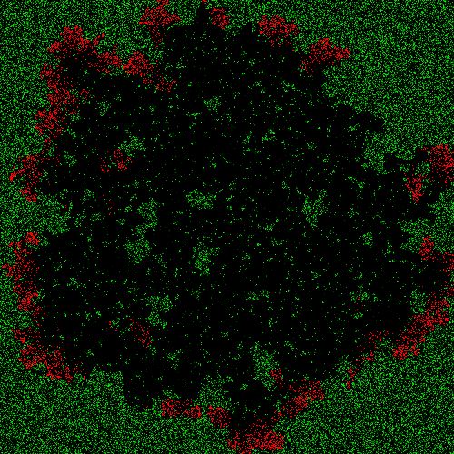

```python
# snapshot with 1M cells
env.snapshot()
```

```python
# 16M cells ~1FPS
env = Environment(shape=(4000, 4000), tree_density=0.55, random_seed=None)

%time env.simulation_step()

# Beyond that, probably makes sense to move the simulation to GPU
```

```
CPU times: user 859 ms, sys: 67.9 ms, total: 927 ms
Wall time: 925 ms
```

# API for RL training

- Implemented from scratch by me
- sticking to OpenAI `gym` API & conventions

```python
def observe(self, drone_pos, fov=[5, 5]):
    """
    Get observations within fov from drone_pos
    """
    x, y = drone_pos
    fov_x, fov_y = int((fov[0] - 1) / 2), int((fov[1] - 1) / 2)
    view = self._state_map[y - fov_y : y + fov_y + 1, x - fov_x : x + fov_x + 1]

    return view
```

```python
def extinguish(self, drone_pos, fov=[3, 3]):
    """
    extinguish cells within fov below drone_pos
    """
    x, y = drone_pos
    fov_x, fov_y = int((fov[0] - 1) / 2), int((fov[1] - 1) / 2)

    slice_y = slice(y - fov_y, y + fov_y + 1)
    slice_x = slice(x - fov_x, x + fov_x + 1)
    view = self._state_map[slice_y, slice_x]

    fire_count = self._state_map[slice_y, slice_x].sum()

    # set sate to 0 (extinguish)
    self._state_map[y - fov_y : y + fov_y + 1, x - fov_x : x + fov_x + 1] = 0

    return fire_count
```

```python
# Standard methods for RL training

def step(self, drone_pos, action, sim_step_every=1):
    """
    environment step
    returns observation and reward
    """
    if self._step_cnt % sim_step_every == 0:
        self.simulation_step(burn_rate=3, ignition_prob=0.2)
    self._step_cnt += 1

    x, y = drone_pos
    observation = self.observe(drone_pos)
    reward = self.extinguish(drone_pos)

    return observation, reward

def reset(self):
    """
    restores the initial state of the environment
    """
    self._state_map = np.zeros(shape, dtype=np.uint8)
    self.ignite_center()


@property
def done(self):
    """
    Termminal state of the environment.
    Returns True if the fire
    a) was put out
    b) died out by itself
    """
    return True if self._state_map.sum() == 0 else False
```

# For more implementation details:

# https://github.com/tomek-l/rl-firefighting

# Agent

- **Agent** is a drone that 'lives' in the lattice
- At each iteration the agent can take one of four actions: $ a \in \{N, S, W, E \} $
- Actions are sampled using $\epsilon$ greedy approach:
  - Agent takes a radom action with probability $\epsilon$
  - Agent takes an action based on policy network with prob. $1 - \epsilon$
- Agent gets reward proportional to the amount of fuel (trees) saved:
  - for not extinguishing any fire, agent gets $r=-1$
  - reward is normalized such that $r \in (-1, 1)$

```python
class Agent:
    def __init__(
        self,
        init_position=[50, 50],
        env_shape=(100, 100),
        fov_shape=(7,7),
        fov_extinguish=(5,5),
        lr=1e-6
    ):

        self._env_shape = env_shape
        self.position = np.array(init_position)
        self._x_bounds = range(fov_shape[1], env_shape[1]-fov_shape[0])
        self._y_bounds = range(fov_shape[0], env_shape[0]-fov_shape[1])
        self._actions, self._traj = self.generate_trajectory()
        self._fov_shape = fov_shape
        self._fov_extinguish = fov_extinguish
        self._view = np.zeros(fov_shape)

        self._policy = torch.nn.Sequential(
            torch.nn.Linear(fov_shape[0]*fov_shape[1], 2048), # input: (the 7x7 segment view)
            torch.nn.ReLU(inplace=True),
            torch.nn.Linear(2048, 2048),
            torch.nn.ReLU(inplace=True),
            torch.nn.Linear(2048, 4), # output: (the values of N, S, W, E actions)
            torch.nn.Sigmoid()
        )

        self._optimizer = torch.optim.Adam(self._policy.parameters(), lr)
```

```python
def action(self, epsilon):
    """
    sample and return action using epsilon-greedy approach
    epsilon is the fraction of random actions
    """
    # sample randomly
    Q_rand = self.random_policy()

    # sample form policy
    view = self._view.flatten() # e.g. 5x5 view of environment state
    self._tensor_in = torch.tensor(view, dtype=torch.float32)
    self._tensor_out = self._policy(self._tensor_in)
    Q_policy = self._tensor_out.detach().numpy() # Q function values approximated by

    # epsilon-greedy
    Q = Q_rand if np.random.rand() < epsilon else Q_policy

    # assign -inf reward to actions that take us to infeasible states
    viable = self.viable_actions()
    Q[~viable] = - np.inf
    action = np.argmax(Q)

    # update position based on chosen action
    delta = action2delta[action]
    self.position += delta

    return action
```

# Training loop

```python
from environment import Environment
from agent import Agent

EPISODES = 1000 # overnight
MAX_ITER = 10000 # episodes will likely finishing after fewer iterations
EPSILON_SCHEDULE = np.linspace(1, 0.05, num=EPISODES) # descreasing epsilon
SAVE_EVERY = 1 # save video every # of episodes
LR = 1e-6

drone = Agent(init_position=[10, 10], lr=LR, fov_shape=(9,9), fov_extinguish=(6,6))
env = Environment(random_seed=None)
for episode, eps in zip(range(EPISODES), EPSILON_SCHEDULE):

    print(f"{episode}/{EPISODES}")
    env.reset()
    drone.position = np.random.randint(10,90,2) # respawn drone at a random positon
    frame_buffer = []

    for it in range(MAX_ITER):
        position = drone.position # drone's (x,y) pos in the env
        action = drone.action(epsilon=eps) # get action

        # environment step (little different than gym's API)
        env.step(position, action)
        drone.observation = env.observe(position, fov=drone._fov_shape) # make observation of env
        reward = env.extinguish(position, fov=drone._fov_extinguish) # reward, normalized in range (-1, 1)
        drone.backprop(reward) # backpropagate through policy network

        # render environment using snapshot() method and add to frame buffer
        frame_buffer.append(env.snapshot(drone.position))

        # in a terminal state -> next episode.
        # (This means all fire extinguished, or died out)
        if env.done: break

    if episode % SAVE_EVERY == 0: drone.save_video(f"episode-{episode}.mp4", frame_buffer)
```

# Results

Run each rollout twice with the same settings:

- once with the firefighting drone
- once without (just let it burn & die out)
- count remaining fuel from each scenario
- the difference between these two is our `efficiency`, the 'dent' we mae into the fire.
- used as a metric of success

# Efficiency

- $ efficiency = \frac{\# trees\ remaining\ (drone) - \# trees\ remaining\ (no\ drone)}{\# total \ trees} = \frac{\# saved \ trees}{\# total \ trees}$
- $ efficiency = 1 $ means we save everything (impossible)
- $ efficiency = 0 $ means we've done nothing
- An optimal policy would yield the highest obtainable efficiency

After 1000 episodes, average efficiency on a 100 test rollouts:

NN policy: `0.381`

Random policy: `0.040`

Heuristic 1 (*lawn-mover trajectory*): `0.114`

Heuristic 2 (*spiral trajectory*): `0.133`